# Zuur et al. 2009 Mixed Modeling Walkthrough

Chapter 10

Michael France Nelson

6/17/2021

## Packages

```r
require(DT)
```

## Boars

|  | Tb | SEX | AgeClass | LengthCT |
| --- | --- | --- | --- | --- |
| 1 | 0 | 1 | 1 | 46.5 |
| 2 | 0 | 2 | 1 | 47 |
| 3 | 0 | 1 | 1 | 48 |
| 4 | 0 | 1 | 1 | 51.5 |
| 5 | 0 | 2 | 1 | 53 |
| 6 | 0 | 2 | 1 | 53 |
| 7 | 0 | 2 | 1 | 53.5 |
| 8 | 0 | 2 | 1 | 61.8 |
| 9 | 0 | 2 | 1 | 62.5 |
| 10 | 0 | 1 | 1 | 67.8 |

[output cut: 647 more lines]

### Boars plots

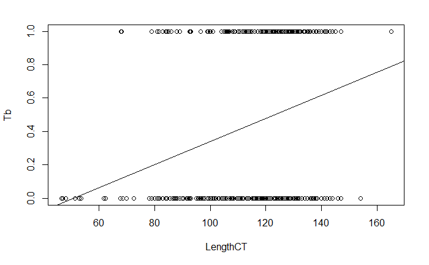

### Boars Modeling Goal Plan

1. An assumption on the distribution of the response variable $Y_i$.
- This also defines the mean and variance of $Y_i$.
2. Specification of the systematic part. This is a function of the explanatory variables.
3. The relationship between the mean value of Yi and the systematic part.
- This is also called the link between the mean and the systematic part.

#### Variables

- The predictor is the head/body length (LengthCT<sub>i</sub>)
- The response is whether or not an individual has TB

#### Distribution of Response

$Y_i$ is $binomial(1, \pi_i)$

- Mean is $1 \times \pi_i$
- Variance is $\pi_i \times (1 - \pi_i)$

#### Predictor Function: Systematic part

Use a linear predictor function $\eta()$.

$\eta(LengthCT_i) = \alpha + \beta \times LengthCT_i$

#### Relationship between expected values and predictors

- Logit link function:
- ‘Log of the odds (ratio)’

The odds is the ratio between the probability that it has TB and the probability it does not: $O_i = \frac{\pi_i}{1 - \pi_i}$

Use an exponential function to model the odds: * In this case we’ll use an exponential function for $\eta()$

$O_i = exp( \alpha + \beta \times LengthCT_i) = \frac{\pi_i}{1 - \pi_i}$

And the logarithm:

- $log(O_i) = \alpha + \beta \times LengthCT_i = log(\frac{\pi_i}{1 - \pi_i})$

Shorthand is:

- $log(O_i) = logit(\pi_i) = \alpha + \beta \times LengthCT_i = \eta(X_i)$

Solving for $\pi_i$:

Let $X_i = \alpha + \beta \times LengthCT_i$

- $X_i = log(\frac{\pi_i}{1 - \pi_i})$
- $e^{X_i} = \frac{\pi_i}{1 - \pi_i}$
- $(1 - \pi_i)e^{X_i} = \pi_i$
- $e^{X_i} - \pi_ie^{X_i} = \pi_i$
- $e^{X_i} = \pi_i + \pi_ie^{X_i}$
- $e^{X_i} = \pi_i (1 + e^{X_i})$
- $\pi_i = \frac{e^{X_i}}{1 + e^{X_i}}$
- $e^{X_i} = \frac{\pi_i}{1 - (e^{X_i} - \pi_ie^{X_i})}$

#### Boar GLM

```r
summary(boar_fit_1)
```

```
Call:
glm(formula = Tb ~ LengthCT, family = binomial, data = boars)

Deviance Residuals:
    Min       1Q   Median       3Q      Max
-1.6095  -1.1200  -0.7089   1.1261   1.9515

Coefficients:
             Estimate Std. Error z value Pr(>|z|)
(Intercept) -3.892109   0.671152  -5.799 6.67e-09 ***
LengthCT     0.031606   0.005588   5.656 1.55e-08 ***
---
Signif. codes:
0 ‘***’ 0.001 ‘**’ 0.01 ‘*’ 0.05 ‘.’ 0.1 ‘ ’ 1

(Dispersion parameter for binomial family taken to be 1)

    Null deviance: 700.76  on 507  degrees of freedom
Residual deviance: 663.56  on 506  degrees of freedom
  (149 observations deleted due to missingness)
AIC: 667.56

Number of Fisher Scoring iterations: 4
```

Plot the model fit

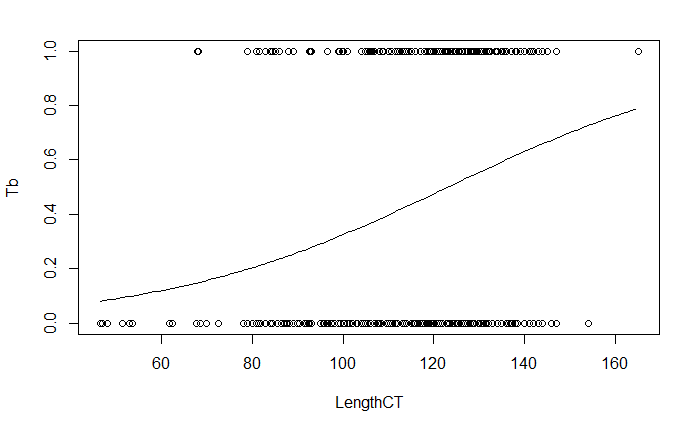

# GLM for Proportions from counts

## Deer Data

```r
names(deer)
```

```
 [1] "Farm"             "BoarPosTB"
 [3] "BoarSampledTB"    "DeerPosTB"
 [5] "DeerSampledTB"    "DeerPosCervi"
 [7] "DeerSampledCervi" "OpenLand"
 [9] "ScrubLand"        "PinePlantation"
[11] "QuercusPlants"    "QuercusTrees"
[13] "WildBoarIndex"    "ReedDeerIndex"
[15] "EstateSize"       "Fenced"
[17] "DeerNegCervi"     "fFenced"
```

### Collinearity Check

Use the authors’ function:

```r
corvif(deer)
```

```
Variance inflation factors
```

|  | GVIF |
| --- | --- |
| Farm | 6.803364 |
| BoarPosTB | 40.472669 |
| BoarSampledTB | 23.616297 |
| DeerPosTB | 62.083063 |
| DeerSampledTB | 72.983262 |
| DeerPosCervi | 40.064921 |
| DeerSampledCervi | 248.659351 |
| OpenLand | 5.197922 |
| ScrubLand | 11.791345 |
| PinePlantation | 42.079050 |

[output cut: 6 more lines]

### Fit a GLM

```r
summary(deer_fit_1)
```

```
Call:
glm(formula = cbind(DeerPosCervi, DeerNegCervi) ~ OpenLand +
    ScrubLand + QuercusPlants + QuercusTrees + ReedDeerIndex +
    EstateSize + fFenced, family = binomial, data = deer)

Deviance Residuals:
    Min       1Q   Median       3Q      Max
-8.0590  -0.8956   0.1093   1.8354   3.7123

Coefficients:
                Estimate Std. Error z value Pr(>|z|)
(Intercept)    3.843e+00  7.772e-01   4.945 7.61e-07
OpenLand      -3.950e+00  6.383e-01  -6.187 6.12e-10
ScrubLand     -7.696e-01  6.140e-01  -1.253 0.210042
QuercusPlants -3.633e-04  2.308e-02  -0.016 0.987439
QuercusTrees   2.290e-03  5.326e-02   0.043 0.965707
ReedDeerIndex  6.689e-02  2.097e-02   3.191 0.001419
EstateSize    -8.218e-05  2.478e-05  -3.316 0.000913
fFenced1      -2.273e+00  5.954e-01  -3.819 0.000134

(Intercept)   ***
OpenLand      ***
ScrubLand
QuercusPlants
QuercusTrees
ReedDeerIndex **
EstateSize    ***
fFenced1      ***
---
Signif. codes:
0 ‘***’ 0.001 ‘**’ 0.01 ‘*’ 0.05 ‘.’ 0.1 ‘ ’ 1

(Dispersion parameter for binomial family taken to be 1)

    Null deviance: 234.85  on 22  degrees of freedom
Residual deviance: 152.79  on 15  degrees of freedom
  (9 observations deleted due to missingness)
AIC: 227.87

Number of Fisher Scoring iterations: 4
```

```r
require(rms)
```